# Part II - Ford GoBike System (FGBS) Data

## Chiebuka Okoro

## (Visualization 1)

# Conversation between me and the newly employed marketing team lead

Him: What user type do we have and what's the ratio amongst them?

Me: Look below. We have two types of users, namely:

1. Customers
2. Subscribers

Him: I was informed that Customers are our premium users. My team and I will work on turning many Subscribers as possible to Customers but first we will do a survey.

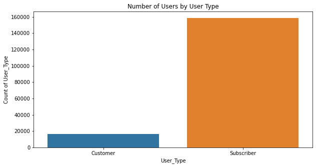

# (Visualization 2)

## Conversation between me and the newly employed marketing team lead - Contd.

Him: I am aware that our company's profit is dependent on rental duration. How does each user type contribute to that?

Me: From the visual below, on average a customer's rental duration is more than twice than that of a subscriber

Him: Wow, that's a whole lot translating into profits. Imagine the numbers we can reach if we can turn more subscribers to customers. I think I forsee a marketing campaign once the survey is concluded.

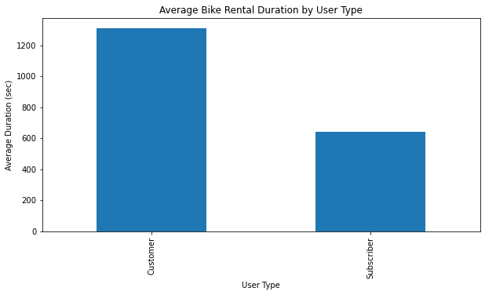

# (Visualization 3)

## Conversation between me and the newly employed marketing team lead - Contd.

Him: We want to do a promo for all user but we need to know the age distribution of our users so as to finalize the details of the promo

Me: Form the chat below, majority of our users fall between age 18 and 40.

Him: Thanks for your time, I will take this back to the team. Do enjoy the rest of your day.

Me: Thanks.

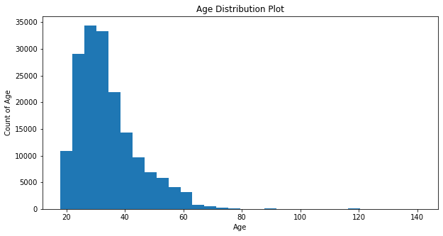